# HollisT_Week6 Assignment 6.2

Tim Hollis

2025-10-16

# The Law of Large Numbers: Bigger Really is Better (When It Comes to Sample Sizes)

We will explore and demonstrate one of the most fundamental concepts in probability: the Law of Large Numbers. This principle is the “why” behind the headline’s claim, it assures us that as a sample size grows, the experimental average of our results will get closer and closer to the theoretical expected value. We will bring this concept to life through simulations and examples, and we will see precisely why **bigger really is better** in the world of statistics.

### **Die Roll Simulation**

We begin by simulating repeated rolls of a fair six-sided die. The expected value of a single roll is 3.5, but this value is not actually possible on any individual roll, the only possibilities are whole numbers 1,2,3,4,5, and 6, so the 3.5 is never itself going to be a value obtained when rolling the die, instead a cumulative average. We’ll explore how the average of many rolls converges toward this expected value.

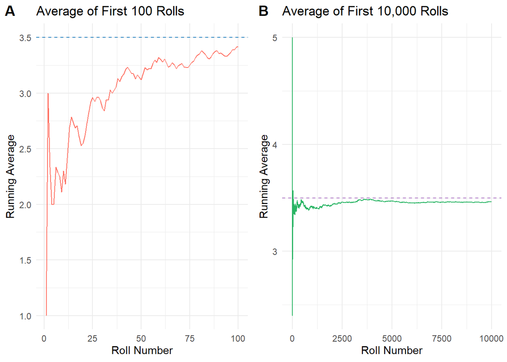

```r
# Simulate 100 rolls
rolls_100 <- sample(1:6, size = 100, replace = TRUE)
avg_100 <- cumsum(rolls_100) / seq_along(rolls_100)
df_100 <- data.frame(Roll = 1:100, Average = avg_100)

plot_100 <- ggplot(df_100, aes(x = Roll, y = Average)) +
  geom_line(color = '#FF6F61') +
  geom_hline(yintercept = 3.5, linetype = 'dashed', color = '#2E86C1') +
  labs(title = 'Average of First 100 Rolls', x = 'Roll Number', y = 'Running Average')

# Simulate 10,000 rolls
rolls_10000 <- sample(1:6, size = 10000, replace = TRUE)
avg_10000 <- cumsum(rolls_10000) / seq_along(rolls_10000)
df_10000 <- data.frame(Roll = 1:10000, Average = avg_10000)

plot_10000 <- ggplot(df_10000, aes(x = Roll, y = Average)) +
  geom_line(color = '#28B463') +
  geom_hline(yintercept = 3.5, linetype = 'dashed', color = '#AF7AC5') +
  labs(title = 'Average of First 10,000 Rolls', x = 'Roll Number', y = 'Running Average')

# Display side by side
plot_grid(plot_100, plot_10000, labels = c('A', 'B'), ncol = 2)
```

### **Red vs. Green Ball Draws**

Next, we simulate drawing balls from a box containing 30 red and 15 green balls, with replacement. The expected proportion of red balls is 30/45 = 0.6667 and green is 15/45 = .3333. We’ll visualize how the observed proportion converges over time

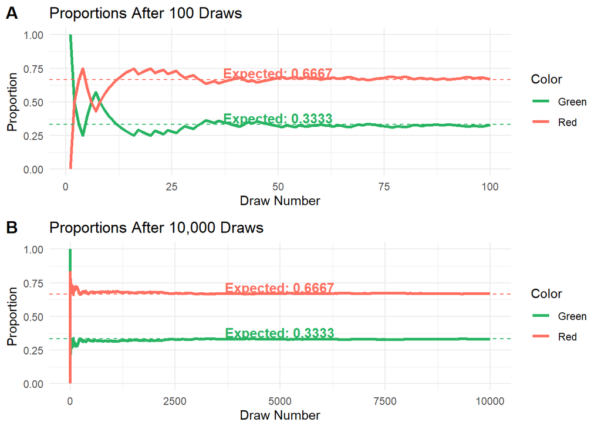

```r
# Simulate 100 draws
set.seed(123)
colors <- c(rep('red', 30), rep('green', 15))
draws_100 <- sample(colors, size = 100, replace = TRUE)
red_100 <- cumsum(draws_100 == 'red') / seq_along(draws_100)
green_100 <- cumsum(draws_100 == 'green') / seq_along(draws_100)
df_100 <- data.frame(Draw = 1:100, Red = red_100, Green = green_100)
df_100_long <- pivot_longer(df_100, cols = c('Red', 'Green'), names_to = 'Color', values_to = 'Proportion')

# Simulate 10,000 draws
draws_10000 <- sample(colors, size = 10000, replace = TRUE)
red_10000 <- cumsum(draws_10000 == 'red') / seq_along(draws_10000)
green_10000 <- cumsum(draws_10000 == 'green') / seq_along(draws_10000)
df_10000 <- data.frame(Draw = 1:10000, Red = red_10000, Green = green_10000)
df_10000_long <- pivot_longer(df_10000, cols = c('Red', 'Green'), names_to = 'Color', values_to = 'Proportion')

# Plot for 100 draws
plot_100 <- ggplot(df_100_long, aes(x = Draw, y = Proportion, color = Color)) +
  geom_line(size = 1.2) +
  geom_hline(yintercept = 30/45, linetype = 'dashed', color = '#FF6F61') +
  geom_hline(yintercept = 15/45, linetype = 'dashed', color = '#28B463') +
  annotate('text', x = 50, y = 0.6667 + 0.05, label = 'Expected: 0.6667', fontface = 'bold', color = '#FF6F61', size = 4) +
  annotate('text', x = 50, y = 0.3333 + 0.05, label = 'Expected: 0.3333', fontface = 'bold', color = '#28B463', size = 4) +
  scale_color_manual(values = c('Red' = '#FF6F61', 'Green' = '#28B463')) +
  labs(title = 'Proportions After 100 Draws', x = 'Draw Number', y = 'Proportion')

# Plot for 10,000 draws
plot_10000 <- ggplot(df_10000_long, aes(x = Draw, y = Proportion, color = Color)) +
  geom_line(size = 1.2) +
  geom_hline(yintercept = 30/45, linetype = 'dashed', color = '#FF6F61') +
  geom_hline(yintercept = 15/45, linetype = 'dashed', color = '#28B463') +
  annotate('text', x = 5000, y = 0.6667 + 0.05, label = 'Expected: 0.6667', fontface = 'bold', color = '#FF6F61', size = 4) +
  annotate('text', x = 5000, y = 0.3333 + 0.05, label = 'Expected: 0.3333', fontface = 'bold', color = '#28B463', size = 4) +
  scale_color_manual(values = c('Red' = '#FF6F61', 'Green' = '#28B463')) +
  labs(title = 'Proportions After 10,000 Draws', x = 'Draw Number', y = 'Proportion')

# Display stacked
plot_grid(plot_100, plot_10000, labels = c('A', 'B'), nrow = 2)
```

#### **Summary**

In both the die roll and ball draw simulations, we observed how empirical averages and proportions converge toward their theoretical expectations as the number of trials increases. The die roll average stabilized near 3.5, despite no single roll ever producing that value, a clear illustration of the Law of Large Numbers. Similarly, the proportion of red and green balls drawn from the box approached 0.6667 and 0.3333 respectively, reinforcing the reliability of long-run frequencies in probabilistic systems.

These simulations highlight the importance of sample size in reducing variability and improving the accuracy of estimates. Early fluctuations are common, but with enough trials, randomness gives way to predictability.

### **LLN: Comparing SDs and Means**

To reinforce the concept of convergence, we now compare how both sample means and sample standard deviations behave as sample size increases.

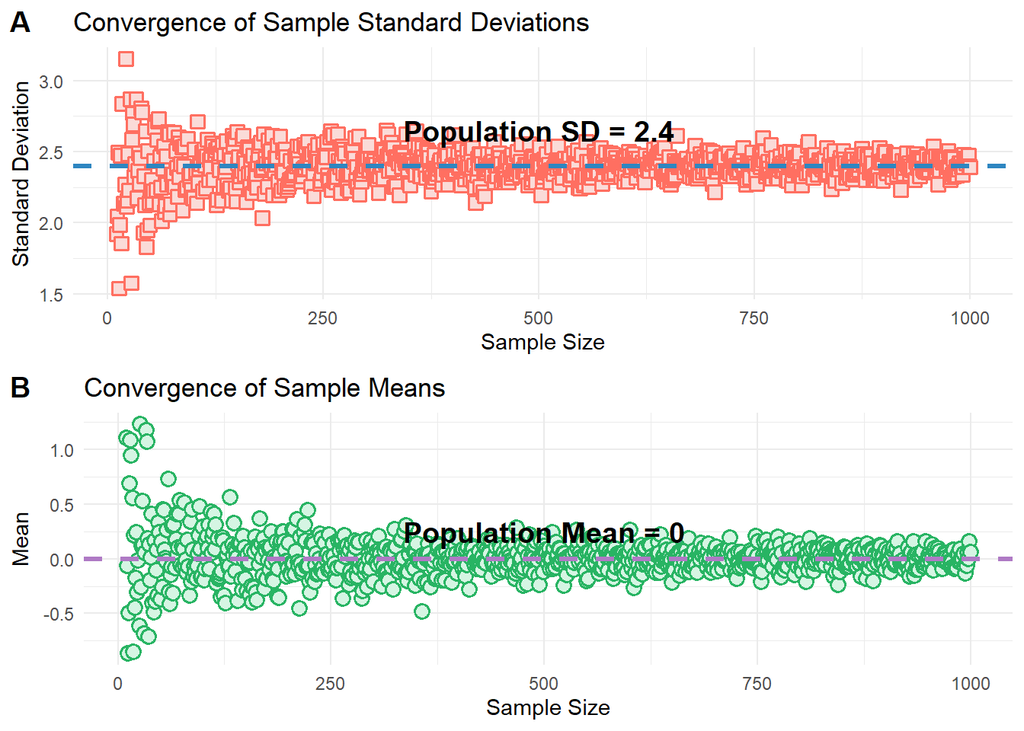

```r
# Population with known standard deviation

#Programming: rnorm() generates a standard normal distribution. We then normalize it to SD = 1 and rescale to SD = 2.4.

#Statistics: This ensures our population has a known, fixed standard deviation — critical for testing convergence.


pop_std <- 2.4
populationN <- 10^6
population <- rnorm(populationN)
population <- population / sd(population) * pop_std

# Sample sizes

samplesizes <- seq(10, 1000)

# Initialize vectors

samplestds <- numeric(length(samplesizes))
samplemeans <- numeric(length(samplesizes))

# Run simulation

for (i in seq_along(samplesizes)) {
  sample <- sample(population, size = samplesizes[i], replace = TRUE)
  samplestds[i] <- sd(sample)
  samplemeans[i] <- mean(sample)
}

# Create data frames

df_sd <- data.frame(SampleSize = samplesizes, Value = samplestds, Type = 'Standard Deviation')
df_mean <- data.frame(SampleSize = samplesizes, Value = samplemeans, Type = 'Mean')
df_combined <- rbind(df_sd, df_mean)

#Plot

plot_sd <- ggplot(df_sd, aes(x = SampleSize, y = Value)) +
  geom_point(color = '#FF6F61', fill = '#FADBD8', shape = 22, size = 3, stroke = 0.8) +
  geom_hline(yintercept = pop_std, linetype = 'dashed', color = '#2E86C1', linewidth = 1.2) +
annotate('text', x = 500, y = pop_std + 0.25, label = 'Population SD = 2.4',
         fontface = 'bold', color = 'black', size = 5) +
  labs(title = 'Convergence of Sample Standard Deviations',
       x = 'Sample Size',
       y = 'Standard Deviation')

plot_mean <- ggplot(df_mean, aes(x = SampleSize, y = Value)) +
  geom_point(color = '#28B463', fill = '#D5F5E3', shape = 21, size = 3, stroke = 0.8) +
  geom_hline(yintercept = 0, linetype = 'dashed', color = '#AF7AC5', linewidth = 1.2) +
  annotate('text', x = 500, y = 0 + 0.25, label = 'Population Mean = 0',
         fontface = 'bold', color = 'black', size = 5) +
  labs(title = 'Convergence of Sample Means',
       x = 'Sample Size',
       y = 'Mean')

# Display vertically stacked
plot_grid(plot_sd, plot_mean, labels = c('A', 'B'), nrow = 2)
```

#### **Summary**

While the Law of Large Numbers guarantees convergence of sample means to the population mean (in this case, 0), we observe that sample standard deviations also stabilize around the true population value of 2.4.

This comparison highlights that while LLN is formally defined for means, the principle of convergence applies broadly to other descriptive statistics, especially when samples are large and randomly drawn.

# Reflection on Assignment 1 of 2 this week

### **What Was Easy or Logical**

- Conceptual clarity: The Law of Large Numbers (LLN) was intuitive to demonstrate through simulations. The idea that averages stabilize with larger samples felt logical, especially when visualized with cumulative plots.
- Code modularity: Structuring simulations into clear blocks (die rolls, ball draws, SD/mean comparisons) made the workflow easy to follow and debug.
- Visual storytelling: Using ggplot2 and cowplot to juxtapose small vs. large sample plots helped reinforce the narrative — bigger really is better.
- Annotation and color choices: Labeling expected values and using distinct color palettes made the plots visually digestible and pedagogically effective.

### **What I Will Stop Doing**

- Hardcoding values without commentary: I’ll avoid inserting constants (like 2.4 or 0.6667) without explaining their origin or statistical relevance. Every number deserves a pedagogical anchor.
- Over-relying on default ggplot themes: While theme_minimal() is clean, I’ll stop assuming it’s always the best fit — sometimes more contrast or gridlines help clarify convergence.

### **What I Will Continue Doing**

- Using cumulative averages and proportions: These are powerful tools for demonstrating convergence and will remain a staple in my simulation toolkit.
- Annotating plots for clarity: Bold labels, dashed lines, and color-coded expectations make statistical concepts more accessible — I’ll keep refining this visual polish.
- Structuring code for readability: Chunking simulations, labeling plots, and using consistent naming conventions helped both me and my instructor follow the logic — I’ll continue prioritizing clarity and maintainability.